# “Homework 2”

Ballesteros, Mele

# Part I

#### **3.16**

You are diagnosed with an uncommon disease. You know that there only is a 1% chance of getting it. Use the letter $D$ for the event “you have the disease” and $T$ for “the test says so.” It is known that the test is imperfect: $P(T |D)=0 .98$ and $P(T^c|D^c)=0 .95$:

1. Given that you test positive, what is the probability that you really have the disease?
2. You obtain a second opinion: an independent repetition of the test. You test positive again.Given this, what is the probability that you really have the disease?

**a.** We have to apply here Bayes Theorem:

$$P(D|T)=\dfrac{P(T|D)P(D)}{P(T|D)P(D)+P(T|D^c)P(D^c)}=\dfrac{0.98\cdot 0.01}{0.98\cdot 0.01+0.05\cdot 0.99}=0.17$$

**b.** We denote now $T_i$ the possitive result of test $i$, with $i= 1, 2$. Also we are using independence condition between both tests: $P(T_2\cap T_1|D)=P(T_2|D)P(T_1|D)$.

Using Bayes Theorem again we gave:

\begin{eqnarray} P(D|T_2 \cap T_1) = \dfrac{P(T_2 \cap T_1|D)P(D)}{P(T_2\cap T_1|D)P(D)+P(T_2\cap T_1|D^c)P(D^c)}= \\ =\dfrac{P(T_2|D)P(T_1|D)P(D)}{P(T_1|D)P(T_2|D)P(D)+P(T_1|D^c)P(T_2|D^c)P(D^c)}= \\ =\dfrac{0.98\cdot 0.98 \cdot 0.01}{0.98\cdot 0.98 \cdot 0.01+0.05\cdot 0.05 \cdot 0.99}=0.80 \end{eqnarray}

#### **5.1**

Let X be a continuous random variable with probability density function:
$$f(x)=\left\{\begin{matrix}
\frac{3}{4} & \text{for }\ 0\leq x\leq 1 \\\
\frac{1}{4} & \text{if }\ 2\leq x\leq 3 \\
0 & \text{elsewhere }\
\end{matrix}\right.$$

1. Draw the graph of f.
2. Determine the distribution function F of X, and draw its graph.

**a** Here there are the R commands to plot the $f(x)$ function

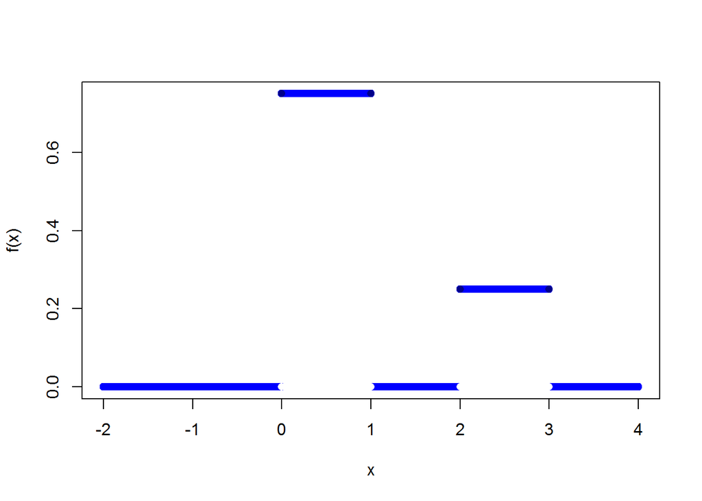

```r
x= seq(-2,+4, by=0.01)
fx= (0<= x & x<=1) * 3/4 + (2<= x & x<= 3)* 1/4
plot(x,fx, ylab = 'f(x)', col='blue')
points(c(0,1,2,3),c(0,0,0,0),pch=16,bg='black', col='white')
points(c(0,1,2,3),c(3/4,3/4,1/4,1/4), pch=16, bg='black', col='blue4')
```

**b** considering that the CDF is: $F_X(x)=P(X\leq x)$ so for this case $F_X(x)=\int_{-\infty}^{x} f(x)dx$ , so:
$$F_X(x)=\left\{\begin{matrix}
0 & \text{for }\ x < 0 \\\
\frac{3b}{4} & \text{for}\ 0\leq x < 1 \\
\frac{3}{4} & \text{for}\ 1\leq x < 2 \\
\frac{b}{4}+\frac{1}{4} & \text{for}\ 2\leq x < 3\\
1 & \text{if}\ x\geq3\\
\end{matrix}\right.$$

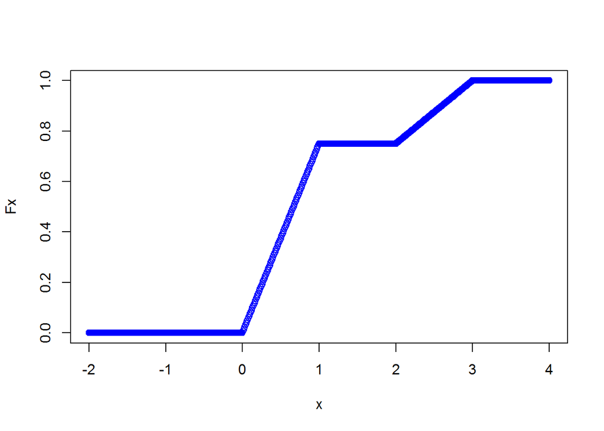

```r
x=seq(-2,4,by=0.01)
Fx=(x>=0 & x<1)*3*x/4 + (x>=1 & x<2)*3/4 + (x>=2 & x<3)*(1/4+ x/4)+ (x>=3)*1
plot(x,Fx, col='blue')
```

#### **5.3**

Let a continuous random variable $X$ be given that takes values in $[0,1]$ , and whose distribution function $F$ :
$$F(x)= 2x^2 -x^4 \mbox{ for } 0\leq x \leq 1$$

1. compute $P(\frac{1}{4}< x< \frac{3}{4})$
2. What is the probability density function of X ?

**a.** The probability asked is:

$P(\frac{1}{4}\leq X \leq \frac{3}{4})=F(\frac{3}{4})-F(\frac{1}{4})=2(\frac{3}{4})^2-(\frac{3}{4})^4-[2(\frac{1}{4})^2-(\frac{1}{4})^4]=\frac{11}{16}$

**b.** To get the PDF we just have to derivate:

$$f(x)=\frac{d}{dx} F(x)=4x-4x^3$$

For $0\leq x \leq 1$. For any other value of $x$, $f(x)=0$

#### **5.7**

The score of a student on a certain exam is represented by a number between 0 and 1. Suppose that the student passes the exam if this number is at least $0.55$. Suppose we model this experiment by a continuous random variable S, the score, whose probability density function is given by
$$f(x)=\left\{\begin{matrix}
4x & \text{for }\ 0\leq x \leq \frac{1}{2} \\\
4-4x & \text{for}\ \frac{1}{2}\leq x \leq 1 \\
0 & \text{elsewhere}\\
\end{matrix}\right.$$

1. What is the probability that the student fails the exam?
2. What is the score that he will obtain with a 50% chance, in other words, what is the 50th percentile of the score distribution?

**a** The probability that a student fails the exam is $P(\text{failure})=P(X<0.55)$ so:
$$P(X<0.55)=\int_{-\infty}^{0.55} f(x)dx=\int_{0}^{0.5} 4xdx + \int_{0.5}^{0.55} (4-4x)dx= 0.595$$

**b** The Quintile function is defined by $Q(p)= \inf{\{x \mbox{ such that } F(x)=p\}}$ so:
$$Q(0.5)= \inf{\{ x | F(x)=0.5 \}} =\inf{\{ x | \int_{-\infty}^{x}f(x)dx\}}=\inf{\{ x | \int_0^{x}4xdx \}}=\inf{\{x | 2x^2=0.5\}}$$
$$x=0.5$$
$$Q(0.5)=0.5$$

#### **5.11**

Compute the median of an $Exp(\lambda)$ distribution.

The distribution is $f_X(x)=Exp(\lambda)=\lambda e^{-\lambda x}$ with a CDF $F_X(x)=1-e^{-\lambda x}$ if $0\leq x$.

The median is the point where $F_X(x)=0.5$, therefore we have to solve the following equation:

$0.5=1-e^{-\lambda x}$

$x=\frac{ln(2)}{\lambda}$

#### **5.14**

Determine the ‘10-th’ percentile of a standard normal distribution

The ‘10-th’ percentile of a standard normal distribution is $\Phi(q_{0.1})=0.1$ and it can be found with the table of normal distribution’s CDF:
$$\Phi(X\leq q_{0.1})=0.1=1-0.9=1-\Phi(X\leq q_{0.9})$$
,but $\Phi(q_{0.9}) = \Phi( - q_{0.1})$ and $\Phi(q_{0.9})=1.28$ so:
$$q_{0.1}=-1.28$$

#### **7.3**

For a certain random variable $X$ it is known that $E[X] = 2$, $Var(X) = 3$. What is EX2?

The known equation for the variance is:

$Var(X)=E(X^2)-[E(X)]^2$

So just solving that for $E(X^2)$:

$E(X^2)=[E(X)]^2+Var(X)=2^2+3=7$

#### **7.4**

Let $X$ be a random variable with $E[X] = 2$, $Var(X) = 4$. Compute the expectation and variance of $(3-2X)$

For the change of units rule: $E(3-2X)=3-2E(X)=-1$ and $Var(3-2X)=2^2Var(X)=16$

#### **7.7**

Given is a random variable $X$ with probability density function $f$ given by $f(x) = 0$ for $x<0$, and for x>1, and $f(x)=4x - 4x^3$ for $0\leq x \leq 1$. Determine the expectation and variance of the random variable 2X +3.

We can use the follogin formula to calculate the expectaton values:

$$E[g(x)]=\int g(x)f_X(x)dx$$

So we have then:

\begin{eqnarray} E(2x+3) & = &\int_0^1(2x+3)(4x-4x^3)dx = 4\int_0^1(2x^2-2x^4+3x-3x^3) \\ & = & 4(2/3-2/5+3/2-3/4)=61/15 \\ \end{eqnarray}

In order to calculate the variance, we can take a different approach. Lets firs calculate $E(x)$ and $E(x^2)$:

$$E(X)=\int_0^1xf(x)dx=\int_0^1x(4x-4x^3)dx=8/15$$

$$E(X^2)=\int_0^1x^2f(x)dx=\int_0^1x^2(4x-4x^3)dx=1/3$$

$$Var(X)= E(X^2)-E^2(X)=11/225$$

Now we van apply the following property: $Var(rX+s)=r^2Var(X)$

Which then leds to the following result: $Var(2x+3)=2^2Var(x)=44/225$

#### **9.1**

The joint probabilities $P(X = a,Y = b)$ of discrete random variables $X$ and $Y$ are given in the following table (which is based on the magical square in Albrecht D¨urer’s engraving *Melencolia I* ). Determine the marginal probability distributions of $X$ and $Y$ ,i.e.,determine the probabilities $P(X = a)$ and $P( Y = b)$ for a,b =1,2,3,4.

| b | a1 | a2 | a3 | a4 |
| --- | --- | --- | --- | --- |
| 1 | 16/136 | 3/136 | 2/136 | 13/136 |
| 2 | 5/136 | 10/136 | 11/136 | 8/136 |
| 3 | 9/136 | 6/136 | 7/136 | 12/136 |
| 4 | 4/136 | 15/136 | 14/136 | 1/136 |

The marginal probability is $P(X=a)=P(X=a,Y=\omega)=\sum_{b=1}^4P(X=a,Y=b)=\frac{1}{4}$ for $a\in[1,2,3,4]$

and $P(Y=b)=P(Y=b,X=\omega)=\sum_{a=1}^4P(Y=b,X=a)=\frac{1}{4}$ for $b\in[1,2,3,4]$

#### **9.3**

Let $X$ and $Y$ be two random variables, with joint distribution the Melencolia distribution, given by the table in Exercise 9.1. What is

1. $P(X = Y )$?
2. $P(X+Y = 5)$?
3. $P(1 <X \leq 3,1 <Y \leq 3 )$?
4. $P((X,Y) \in { (1,4)}\mbox{ x }{(1,4)})$?

**a.**$P(X=Y)=\sum_{i=1}^4P(X=i,Y=i)=16/136+10/136+7/136+1/136=1/4$

**b.**$P(X+Y=5)=P(X=1,Y=4)+P(X=4,Y=1)+P(X=2,Y=3)+P(X=3,Y=2)=4/136+13/136+6/136+11/136=1/4$

**c.**$P(1<X\leq 3, 1<X\leq 3)=P(X=2,Y=2)+P(X=2,Y=3)+P(X=3,Y=2)+P(X=3,Y=3)=10/136+6/136+11/136+7/136=1/4$

**d.**$P((X,Y)\exists\lbrace 1,4 \rbrace \times \lbrace 1,4 \rbrace =P(X=1,Y=1)+P(X=1,Y=4)+P(X=4,Y=1)+P(X=4,Y=4)=16/136+13/136+4/136+1/136=1/4$

#### **9.7**

To investigate the relation between hair color and eye color, the hair color and eye color of 5383 persons was recorded. The data are given in the following table:

|  | Hair color |  |  |
| --- | --- | --- | --- |
| Eye color | Fair / red | Medium | Dark /Black |
| Light | 1168 | 825 | 305 |
| Dark | 573 | 1312 | 1200 |

Eye color is encoded by the values 1 (Light) and 2 (Dark), and hair color by 1 (Fair/red), 2 (Medium), and 3 (Dark/black). By dividing the numbers in the table by $5383$, the table is turned into a joint probability distribution for random variables $X$ (hair color) taking values 1 to 3 and $Y$ (eye color) taking values 1 and 2.

1. Determine the joint and marginal probability distributions of $X$ and $Y$.
2. Find out whether $X$ and $Y$ are dependent or independent.

**a.** The joint probability distribution of $X$ and $Y$ is

| b | a |  |  |  |
| --- | --- | --- | --- | --- |
|  | 1 | 2 | 3 | P(Y= b) |
| 1 | 0.22 | 0.15 | 0.06 | 0.43 |
| 2 | 0.11 | 0.24 | 0.22 | 0.57 |
| P(X=a) | 0.33 | 0.39 | 0.28 | 1 |

**b.** Since $P(X = 1,Y = 1)=\frac{1168}{5383} \neq \frac{1741}{5383}\frac{2298}{5383} = P(X = 1)P(Y = 1)$

we answer that $X$ and $Y$ are dependent.

#### **9.12**

The joint probability density function f of the pair $(X,Y)$ is given by $f(x,y)=K(3x^2 +8xy)$ for $0 \leq x \leq 1$ and $0\leq y \leq2$, and $f(x,y) = 0$ for all other values of $x$ and $y$. Here $K$ is some positive constant.

1. Find $K$.
2. Determine the probability $P(2X \leq Y )$.

**a.** To find $K$ we must use the condition that the PDF has to be normalized:

$\int_0^2\int_0^1K(3x^2+8xy)dxdy=10K=1$

$K=1/10$

**b.**

$P(2X\leq Y)=P(X\leq Y/2)=\int_0^2\int_0^{y/2}\frac{1}{10}(3x^2+8xy)dxdy=\frac{1}{10}\int_0^2(y^3/8+y^3)=9/20$

#### **10.8**

Let $X$ and $Y$ be random variables such that $E[X]=2$ , $E[Y ]=3$ , and $Var(X)=4$

1. Show that $E[X^2]= 8$.
2. Determine the expectation of $-2X^2 + Y$.

**a.** Using the know equality $Var(X)=E(X^2)-E(X)^2$ we have:

$$E(X^2)=Var(X)+E(X)^2=4+2^2=8$$

**b.** We can use here the this property: $E(rX+sY)=rE(X)+sE(Y)$:

$$E(-2X^2+Y)=-2E(X^2)+E(Y)=-28+3=-13$$

# Part II

## **1**

Suppose that X has a Unif(0,1) distribution. Construct a random variable $Y = g(X)$ for some deterministic function $g(·)$ such that its $pdf$ will be:

$$f_Y(y)=\left\{\begin{matrix}
\frac{3}{8}y^2 & \text{for }\ y \in (0,2) \\\
0 & \text{ otherwise } \\
\end{matrix}\right.$$

The uniform distribution of X has the following CDF:

$$F_X(x)=\left\{\begin{matrix}
0 & \text{if }\ x<0 \\\
x & \text{if }\ 0\leq x\leq 1 \\
1 & \text{if }\ 1 < x
\end{matrix}\right.$$

Now we calculate the CDF of Y:

$$F_Y(y)=\int f_Y(y)dy=\int\dfrac{3}{8}y^2dy
=\left\{\begin{matrix}
0 & \text{if }\ y<0 \\\
\dfrac{1}{8}y^3 & \text{if }\ 0\leq y\leq 2 \\
1 & \text{if }\ 2 < y
\end{matrix}\right.$$

Now we can develop the following equality:

$$F_Y(f)=P(Y\leq y)=P(g(X)\leq y)=P(X\leq g^{-1}(y))=F_X( g^{-1}(y))= g^{-1}(y)=\dfrac{1}{8}y^3$$

We find now the inverse of the inverse function in the last equality and find that:

$$g(y)=2y^{1/3}$$

Therefore the solution is:

$$Y=g(X)=2X^{1/3}$$

## **2**

In a die-coin experiment, a fair die is rolled and then a fair coin is tossed the number of times showing on the die. Let $N$ denote the die score and $X$ the number of heads. Find $E(X)$ and $Var(X)$.

In the dice-coin experiment, lets first talk about the coin toss. The PMF is simply the binomial distribution. Then the expected value $E_n(X)$ of success $x$ (which denotes de number of heads) in $n$ tosses, is given by:

$$(x)=\sum_{x=1}^n xP(X = x)=\sum_{x=1}^n x \frac{1}{2^n}\binom{n}{x}$$

Now considering the first part of the experiment, the dice, we want to compute the expected value of that expectec value. Since the dice is fair, the probability of each $E_n(x)$ is $1/6$

$$E(E_n(x))=\sum_{n=1}^6 E_n(x)P(E_n(x))=\sum_{n=1}^6 \sum_{x=1}^n x \frac{1}{2^n}\binom{n}{x} \frac{1}{6}=E(x)$$

Also we will need $E(E_n(x^2))$ to calculate the $var(x)$:

$$E(E_n(x^2))=\sum_{n=1}^6 \sum_{x=1}^n x^2 \frac{1}{2^n}\binom{n}{x} \frac{1}{6}=E(x^2)$$

And the variance is of course:

$$Var(x)=E(x^2)-[E(x)]^2$$

We can compute this sums in R as follows:

```r
# Compute expected value of x
sum = 0
for (n in 1:6) {
  for (x in 1:n) {
    sum = sum + x*dbinom(x, size=n, prob=0.5)/6
  }
}

# Compute expected value of x^2
sum2 = 0
for (n in 1:6) {
  for (x in 1:n) {
    sum2 = sum2 + x*x*dbinom(x, size=n, prob=0.5)/6
  }
}
```

Then the result is that $E(x) = 1.75$:

```r
sum
```

```
## [1] 1.75
```

And $Var(x) = 1.60$:

```r
sum2-sum*sum
```

```
## [1] 1.604167
```